# Storms in the United States 1950 - 2011

As stated in the introduction to the course assignment, storms and other severe weather events can cause both public health and economic problems for communities and municipalities. Many severe events can result in fatalities, injuries, and property damage, and preventing such outcomes to the extent possible is a key concern.

## Data Processing

Following libraries that are used for the analysis, and need installing and loading:

```r
## install dplyr if not already done so
if (("dplyr" %in% (installed.packages())) == F) {
        install.packages("dplyr")
}
## install quantmod if not already done so
if (("quantmod" %in% (installed.packages())) == F) {
        install.packages("quantmod")
}
## install quantmod if not already done so
if (("ggplot2" %in% (installed.packages())) == F) {
        install.packages("ggplot2")
}

library(dplyr)
library(quantmod)
library(ggplot2)
```

We download the data for the analysis from the [course file](https://d396qusza40orc.cloudfront.net/repdata/data/StormData.csv.bz2) repository as indicated in the assessment description:

```r
## the name of the dataset file
data_file <- "StormData.csv"

## download dataset file if not already done so
if (!file.exists(data_file)) {
        ## download the dataset
        download.file(url = "https://d396qusza40orc.cloudfront.net/repdata/data/StormData.csv.bz2",
                      destfile = "StormData.csv.bz2", method = "curl")
        system("bunzip2 StormData.csv.bz2")
}

## read the entire dataset into a data frame
rawdata <- read.csv(file = data_file)
```

Now we will take a look at the data and make some transformations. First, check the structure of the data frame:

```r
str(rawdata)
```

```
## 'data.frame':    902297 obs. of  37 variables:
##  $ STATE__   : num  1 1 1 1 1 1 1 1 1 1 ...
##  $ BGN_DATE  : Factor w/ 16335 levels "1/1/1966 0:00:00",..: 6523 6523 4242 11116 2224 2224 2260 383 3980 3980 ...
##  $ BGN_TIME  : Factor w/ 3608 levels "00:00:00 AM",..: 272 287 2705 1683 2584 3186 242 1683 3186 3186 ...
##  $ TIME_ZONE : Factor w/ 22 levels "ADT","AKS","AST",..: 7 7 7 7 7 7 7 7 7 7 ...
##  $ COUNTY    : num  97 3 57 89 43 77 9 123 125 57 ...
##  $ COUNTYNAME: Factor w/ 29601 levels "","5NM E OF MACKINAC BRIDGE TO PRESQUE ISLE LT MI",..: 13513 1873 4598 10592 4372 10094 1973 23873 24418 4598 ...
##  $ STATE     : Factor w/ 72 levels "AK","AL","AM",..: 2 2 2 2 2 2 2 2 2 2 ...
##  $ EVTYPE    : Factor w/ 985 levels "   HIGH SURF ADVISORY",..: 834 834 834 834 834 834 834 834 834 834 ...
##  $ BGN_RANGE : num  0 0 0 0 0 0 0 0 0 0 ...
##  $ BGN_AZI   : Factor w/ 35 levels "","  N"," NW",..: 1 1 1 1 1 1 1 1 1 1 ...
##  $ BGN_LOCATI: Factor w/ 54429 levels ""," Christiansburg",..: 1 1 1 1 1 1 1 1 1 1 ...
##  $ END_DATE  : Factor w/ 6663 levels "","1/1/1993 0:00:00",..: 1 1 1 1 1 1 1 1 1 1 ...
##  $ END_TIME  : Factor w/ 3647 levels ""," 0900CST",..: 1 1 1 1 1 1 1 1 1 1 ...
##  $ COUNTY_END: num  0 0 0 0 0 0 0 0 0 0 ...
```

[output cut: 23 more lines]

For our analysis we’re interested in the following columns as they are described in the code book (National Climatic Data Center’s [record layout document](http://ire.org/media/uploads/files/datalibrary/samplefiles/Storm%20Events/layout08.doc) as referenced on the [Investigative Reporers & Editors](http://ire.org/nicar/database-library/databases/storm-events/) website.):

| Column | Description |
| --- | --- |
| BGN_DATE | The date when the event began |
| EVTYPE | The event type |
| FATALITIES | The number of direct fatalities |
| INJURIES | The number of direct injuries |
| PROPDMG | The damage to the properties |
| PROPDMGEXP | The exponent used to calculate the total amount of property damage |
| CROPDMG | The damage to the crops |
| CROPDMGEXP | The exponent used to calculate the total amount of crop damage |

Using the following code we select the data we’re interested in, and transform values to formats that make the analysis easier:

```r
## create function that will convert character vectors to numeric exponents
convert_exp <- function(exponent) {
        sapply(exponent, function(exponent) {
                ## try converting to numeric
                n_exp = as.numeric(exponent)
                ## if the result is NA...
                if (is.na(n_exp)) {
                        ## ...convert Factor to character vector, and
                        s_exp = toupper(as.character(exponent))
                        ## ...convert according to this table:
                        ## Hundred (H), Thousand (K), Million (M), Billion (B)
                        n_exp = ifelse(s_exp == "H", 2,
                                ifelse(s_exp == "K", 3,
                                ifelse(s_exp == "M", 6,
                                ifelse(s_exp == "B", 9, 0))))
                }
                return(n_exp)
        })
}
## using the function convert_exp convert the columns PROPDMGEXP and CROPDMGEXP into numeric exponents
data <- tbl_df(rawdata) %>%
        ## select the data we're interested in
        select(BGN_DATE, EVTYPE, FATALITIES, INJURIES, PROPDMG, PROPDMGEXP, CROPDMG, CROPDMGEXP) %>%
        ## transform the data into formats we need for our analysis
        mutate(YEAR = as.numeric(format(as.Date(as.character(BGN_DATE), format="%m/%d/%Y %H:%M:%S"), "%Y")),
               EVTYPE = as.character(EVTYPE),
               ## convert exponents using function convert_exp
               PROPDMGEXP = convert_exp(PROPDMGEXP),
               CROPDMGEXP = convert_exp(CROPDMGEXP),
               ## calculate damage using the converted numeric exponents
               PROPDMGCASH = PROPDMG * 10^PROPDMGEXP,
               CROPDMGCASH = CROPDMG * 10^CROPDMGEXP,
               ## calculate total economic damage
               TOTALDMGCASH = PROPDMGCASH + CROPDMGCASH,
               ## drop BGN_DATE column
               BGN_DATE = NULL)
```

Check the values for some of the columns by printing out the unique values:

```r
unique(data$EVTYPE)
```

```
##   [1] "TORNADO"                        "TSTM WIND"
##   [3] "HAIL"                           "FREEZING RAIN"
##   [5] "SNOW"                           "ICE STORM/FLASH FLOOD"
##   [7] "SNOW/ICE"                       "WINTER STORM"
##   [9] "HURRICANE OPAL/HIGH WINDS"      "THUNDERSTORM WINDS"
##  [11] "RECORD COLD"                    "HURRICANE ERIN"
##  [13] "HURRICANE OPAL"                 "HEAVY RAIN"
##  [15] "LIGHTNING"                      "THUNDERSTORM WIND"
##  [17] "DENSE FOG"                      "RIP CURRENT"
##  [19] "THUNDERSTORM WINS"              "FLASH FLOOD"
##  [21] "FLASH FLOODING"                 "HIGH WINDS"
##  [23] "FUNNEL CLOUD"                   "TORNADO F0"
##  [25] "THUNDERSTORM WINDS LIGHTNING"   "THUNDERSTORM WINDS/HAIL"
##  [27] "HEAT"                           "WIND"
##  [29] "LIGHTING"                       "HEAVY RAINS"
```

[output cut: 478 more lines]

```r
unique(data$PROPDMGEXP)
```

```
##  [1] 17 19  1 14 18  4  5 10 11  3  9  7  8 15 12 16  2  6 13
```

```r
unique(data$CROPDMGEXP)
```

```
## [1] 1 9 7 8 5 2 3 6 4
```

```r
data$EVTYPE[grepl("Summary", data$EVTYPE)]
```

```
##  [1] "Summary Jan 17"       "Summary of March 14"  "Summary of March 23"
##  [4] "Summary of March 24"  "Summary of April 3rd" "Summary of April 12"
##  [7] "Summary of April 13"  "Summary of April 21"  "Summary August 11"
## [10] "Summary of April 27"  "Summary of May 9-10"  "Summary of May 10"
## [13] "Summary of May 13"    "Summary of May 14"    "Summary of May 22 am"
## [16] "Summary of May 22 pm" "Summary of May 26 am" "Summary of May 26 pm"
## [19] "Summary of May 31 am" "Summary of May 31 pm" "Summary of June 3"
## [22] "Summary of June 4"    "Summary June 5-6"     "Summary June 6"
## [25] "Summary of June 11"   "Summary of June 12"   "Summary of June 13"
## [28] "Summary of June 15"   "Summary of June 16"   "Summary June 18-19"
## [31] "Summary of June 23"   "Summary of June 24"   "Summary of June 30"
## [34] "Summary of July 2"    "Summary of July 3"    "Summary of July 11"
## [37] "Summary of July 22"   "Summary July 23-24"   "Summary of July 26"
## [40] "Summary of July 29"   "Summary of August 1"  "Summary August 2-3"
## [43] "Summary August 7"     "Summary August 9"     "Summary August 10"
## [46] "Summary August 17"    "Summary August 21"    "Summary August 28"
## [49] "Summary September 4"  "Summary September 20" "Summary September 23"
## [52] "Summary Sept. 25-26"  "Summary: Oct. 20-21"  "Summary: October 31"
## [55] "Summary: Nov. 6-7"    "Summary: Nov. 16"     "Summary of March 23"
## [58] "Summary of April 12"  "Summary of April 21"  "Summary of May 22"
## [61] "Summary of June 6"    "Summary August 4"     "Summary of June 3"
## [64] "Summary of June 10"   "Summary of June 13"   "Summary of June 18"
## [67] "Summary August 10"    "Summary August 11"    "Summary September 3"
## [70] "Summary: Sept. 18"    "Summary September 23" "Summary: Nov. 16"
## [73] "Blizzard Summary"
```

The values are all summaries of some other dates. Checking the values of the raw data:

```r
summaries <- rawdata[grepl("Summary", rawdata$EVTYPE), ]

## Check whether this data contains any useful data:
sum(summaries$FATALITIES)
```

```
## [1] 0
```

```r
sum(summaries$INJURIES)
```

```
## [1] 0
```

```r
sum(summaries$PROPDMG)
```

```
## [1] 0
```

```r
sum(summaries$CROPDMG)
```

```
## [1] 0
```

All these columns contain zero (0) values, so we can discard them:

```r
data <- filter(data, grepl("Summary", EVTYPE) == FALSE)
```

Considering that the data starts from years 1950 - 2011 we should adjust the damage sums for inflation:

```r
invisible(getSymbols("CPIAUCSL", src='FRED'))
avg_cpi <- apply.yearly(CPIAUCSL, mean)
conversion_factors <- as.data.frame(avg_cpi / as.numeric(avg_cpi['2011']))
conversion_factors$YEAR = as.numeric(format(as.Date(rownames(conversion_factors)), '%Y'))
colnames(conversion_factors)[1] = 'FACTOR'

data = merge(data, conversion_factors, by='YEAR')
data$TOTALDMGCASH = data$TOTALDMGCASH * data$FACTOR
```

Beside the summary rows, we’ve seen values that are slightly different, but have very similar meaning in terms of the type of the event, e.g. “FLOOD”" and “FLOODING”, or contain typos, e.g. “THUNDER” and “THUNER”" . We will try to merge them into a smaller set of event types to make the analysis exacter:

```r
## create function that will merge similar event type names
merge_evtypes <- function(evtype) {
        UPR = toupper(gsub("^\\s+|\\s+$", "", evtype))
        new_evtype = ifelse(grepl("HURRICANE|TYPHOON", UPR), "HURRICANE",
                ifelse(grepl("(THUNDER|THUNER|THUDER|THUNDEER|TUNDER|TSTM).?", UPR) & !grepl("NON", UPR), "THUNDERSTORM",
                ifelse(grepl("(RECORD|HEAVY|EXCESSIVE|UNSEASONAL).?RAIN.*", UPR) & !grepl("THUNDER|TSTM|NON", UPR), "HEAVY RAIN",
                ifelse(grepl("STORM SURGE", UPR), "STORM SURGE",
                ifelse(grepl("(GRASS|WILD|FOREST).?FIRE", UPR), "WILD FIRE",
                ifelse(grepl("HEAT", UPR), "HEAT",
                ifelse(grepl("COLD|FREEZE|FROST", UPR) & !grepl("AIR|FOG|WET|SNOW", UPR), "",
                ifelse(grepl("(HIGH|BLOWING|STRONG).?WIND", UPR), "",
                ifelse(grepl("FLOOD", UPR), "FLOOD",
                ifelse(grepl("TROPICAL.?STORM", UPR), "TROPICAL STORM",
                ifelse(grepl("FOG", UPR), "FOG",
                ifelse(grepl("WINTRY|WINTER", UPR), "WINTER WEATHER",
                ifelse(grepl("HAIL.?", UPR), "HAIL",
                ifelse(grepl("BLOWING.?SNOW", UPR), "BLOWING SNOW",
                ifelse(grepl("DRY.?MICROBURST", UPR), "DRY MICROBURST",
                ifelse(grepl("FREEZING.?(DRIZZLE|RAIN|SPRAY)", UPR), "FREEZING RAIN",
                ifelse(grepl("(RECORD|HEAVY).?SNOW", UPR), "HEAVY SNOW",
                ifelse(grepl("ICE|ICY", UPR), "ICE",
                ifelse(grepl("LIGHTNING", UPR), "LIGHTNING",
                ifelse(grepl("RIP.?CURRENT.?", UPR), "RIP CURRENT",
                ifelse(grepl("TORNADO|TORNDAO", UPR), "TORNADO",
                ifelse(grepl("GUSTY.*WIND.*", UPR), "GUSTY WIND",
                ifelse(grepl("COLD.*WET.*", UPR), "COLD AND WET",
                ifelse(grepl("EXTREME.*WIND.*(DAMAGE|STORM)*", UPR), "EXTREME WIND",
                ifelse(grepl("HIGH.*SURF.*", UPR), "HIGH SURF",
                ifelse(grepl("LAKE.*EFFECT.*SNOW", UPR), "LAKE EFFECT SNOW",
                ifelse(grepl("LAND.*(SLIDE|SLIDES|SLUMP|SPOUT)", UPR), "LAND SLIDE",
                ifelse(grepl("LIGHTING|LIGHTNING|LIGNTNING", UPR), "LIGHTNING",
                ifelse(grepl("MICROBURST", UPR), "MICROBURST",
                ifelse(grepl("MUD.*SLIDE.*", UPR), "MUD SLIDE",
                ifelse(grepl("WATERSPOUT.*", UPR), "WATERSPOUT", UPR)))))))))))))))))))))))))))))))

        return(new_evtype)
}
## merge similar event types
data$EVTYPE <- sapply(data$EVTYPE, merge_evtypes)
```

## Results

When analysing the data we’re looking at aggregated total numbers for fatalities, injuries and property and crop damage.

#### Across the United States, which types of events (as indicated in the EVTYPE variable) are most harmful with respect to population health?

Calculate total fatalities and injuries per event type and select the top ten harmful events:

```r
fatalities <- data %>%
        ## group data by event type
        group_by(EVTYPE) %>%
        ## calculate total fatalities per event type
        summarize(FATALITIES = sum(FATALITIES)) %>%
        ## discard data where event type value is empty, or fatalities value is zero
        filter(EVTYPE != "" & FATALITIES > 0) %>%
        ## sort by fatalities in descending order
        arrange(desc(FATALITIES)) %>%
        ## selet the first 10 rows
        slice(1:10)

injuries <- data %>%
        ## group data by event type
        group_by(EVTYPE) %>%
        ## calculate total fatalities per event type
        summarize(INJURIES = sum(INJURIES)) %>%
        ## discard data where event type value is empty, or fatalities value is zero
        filter(EVTYPE != "" & INJURIES > 0) %>%
        ## sort by fatalities in descending order
        arrange(desc(INJURIES)) %>%
        ## selet the first 10 rows
        slice(1:10)
```

Plot fatalities by event type:

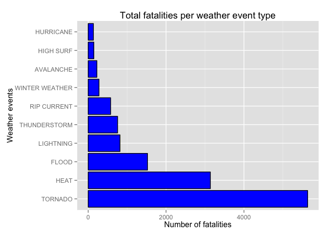

```r
ggplot(data = fatalities, aes(x = EVTYPE, y = FATALITIES)) +
        geom_bar(position="dodge", stat='identity', colour="black", fill="blue") +
        coord_flip() +
        ggtitle("Total fatalities per weather event type") +
        xlab("Weather events") + ylab("Number of fatalities") +
        scale_x_discrete(limits = fatalities$EVTYPE)
```

The plot above shows that the most harmful weather events to human population are tornadoes, heat waves and floods

Plot injuries by event type:

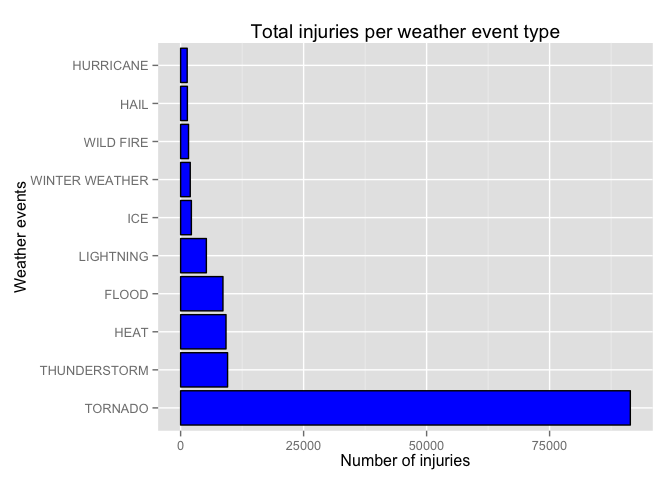

```r
ggplot(data = injuries, aes(x = EVTYPE, y = INJURIES)) +
        geom_bar(position="dodge", stat='identity', colour="black", fill="blue") +
        coord_flip() +
        ggtitle("Total injuries per weather event type") +
        xlab("Weather events") + ylab("Number of injuries") +
        scale_x_discrete(limits = injuries$EVTYPE)
```

The plot above shows that the weather event that causes the most injuries are tornadoes

#### Across the United States, which types of events have the greatest economic consequences?

```r
economic_damage <- data %>%
        group_by(EVTYPE) %>%
        summarize(DAMAGE = sum(TOTALDMGCASH)) %>%
        filter(EVTYPE != "" & DAMAGE > 0) %>%
        arrange(desc(DAMAGE)) %>%
        slice(1:10)
```

Plot economic damage by event type:

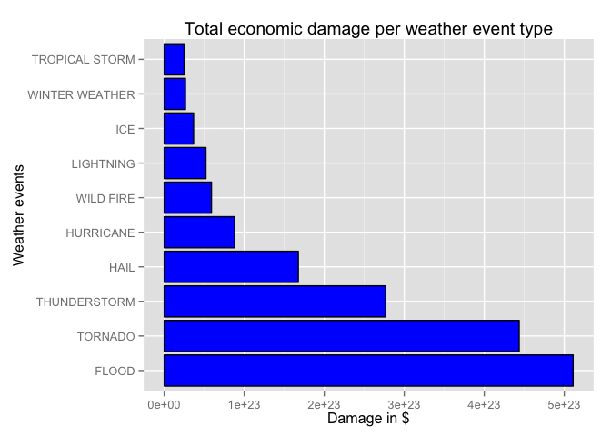

```r
ggplot(data = economic_damage, aes(x = EVTYPE, y = DAMAGE)) +
        geom_bar(position="dodge", stat='identity', colour="black", fill="blue") +
        coord_flip() +
        ggtitle("Total economic damage per weather event type") +
        xlab("Weather events") + ylab("Damage in $") +
        scale_x_discrete(limits = economic_damage$EVTYPE)
```